# Práctica1SMDE_GardellaGarciaRicard

Ricard Gardella Garcia

30/9/2017

## FIRST QUESTION: GENERATE A RANDOM SAMPLE.

On this exercise, we are going to start working with probability distributions. The first work to do is to generate more than 200 observations of your assigned probability distribution. We are going to generate this using a Spreadsheet. Now you must import this distribution to R and test the fitting of the values with a new sample now generated by R. Use for the fitting a Chi-square test.

Here, a normal distribution is generated and showed using the “summary” command. We can see the mean of the distribution, the min, the max, the median and the values of the 1st and 3rd quartil. The values of the distribution are random.

```r
v1=rnorm(200, mean=0, sd=1)
summary(v1)
```

```
##      Min.   1st Qu.    Median      Mean   3rd Qu.      Max.
## -2.486000 -0.693900 -0.010420 -0.006789  0.745900  2.540000
```

The data of the normal distribution into a data frame

```r
taula_v1=data.frame(x1=v1)
```

Here the intervals are defined and the categories to be used aswell.

```r
taula_v1_cat=transform(taula_v1, cat =
                         ifelse(x1 < -1,"-1",
                         ifelse(x1 < -0.5,"-0.5",
                          ifelse(x1 < 0,"0",
                          ifelse(x1 < 0.5,"0.5",
                          ifelse(x1 <1,"1","Inf"))))))
```

After this step, an excel spreadsheet has to be generated in order to complete this exercice, then, we must generate random values and then apply the same method as above to fill a new columns with the categories that later will be used to compare both results.

```r
library(readxl)
ExcelPract1Estadistica <- read_excel("~/Documents/Master Data science/SMDE/Prácticas/Práctica1/ExcelPract1Estadistica.xlsx")
ExcelPract1Estadistica=transform(ExcelPract1Estadistica, Categoria =
                         ifelse(SPECIAL < -1,"-1",
                                ifelse(SPECIAL < -0.5,"-0.5",
                                       ifelse(SPECIAL < 0,"0",
                                              ifelse(SPECIAL < 0.5,"0.5",
                                                     ifelse(SPECIAL <1,"1","Inf"))))))
```

Now, we count the amount of each categories from both excel and r

```r
taula_freq_v1=as.data.frame(with(taula_v1_cat, table(cat)))
taula_freq_excel=as.data.frame(with(ExcelPract1Estadistica, table(Categoria)))
```

A table that count the categories of both distributions is created

```r
taula_freq=data.frame(x1=taula_freq_v1[2],x2=taula_freq_excel[2])
```

Then, we can apply the chisquare test. That test give us the x squared and the P value.

```r
Test=chisq.test(taula_freq, correct=FALSE)
Test
```

```
##
##  Pearson's Chi-squared test
##
## data:  taula_freq
## X-squared = 1.064, df = 5, p-value = 0.9572
```

Also, we can represent the excel and r distributions using histograms in order to see the diference in a more visual way.

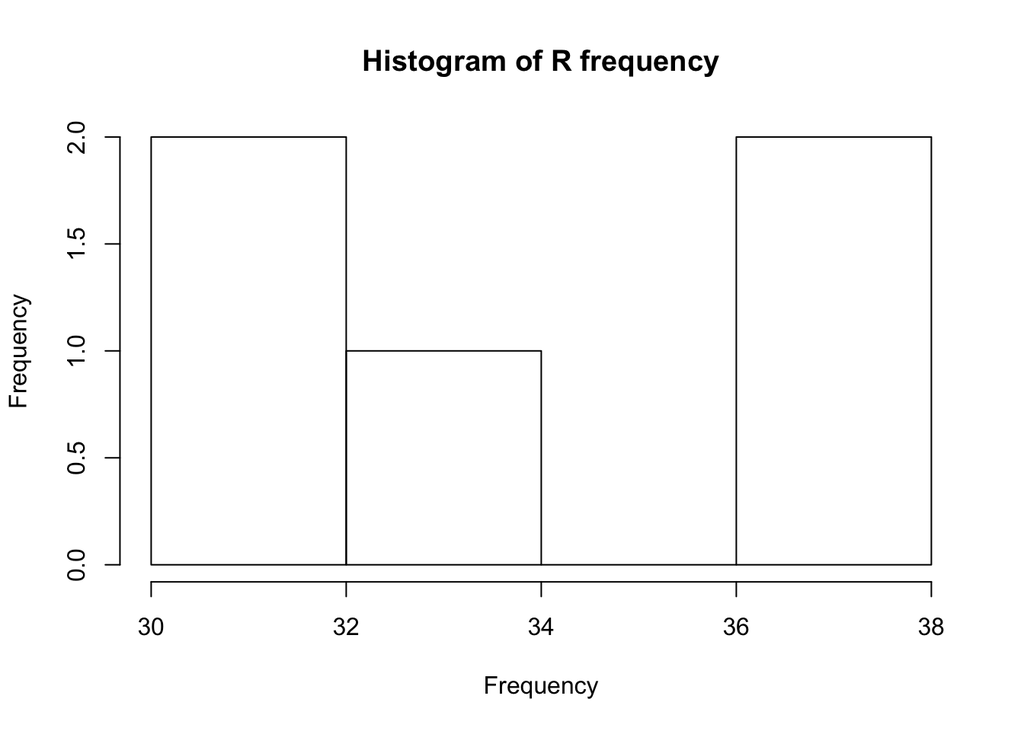

```r
hist(taula_freq[2:6,1],
     main="Histogram of R frequency",
     xlab="Frequency")
```

```r
hist(taula_freq[2:6,2],
     main="Histogram of Excel frequency",
     xlab="Frequency")
```

[output not shown]

Now will implement the same, but for an exponential distribution also using a exponential distribution in excel.

```r
v2=rexp(200)
ExcelPract1EstadisticaExp <- read_excel("~/Documents/Master Data science/SMDE/Prácticas/Práctica1/ExcelPract1EstadisticaExp.xlsx")
taula_v2=data.frame(x2=v2)
```

Perform the same than before in order to perform the chisquare test. As we can see in the chi-square test, the value is near 0 so the test is correct.

```r
taula_v2_cat=transform(taula_v2, cat =
                         ifelse(x2 < -1,"-1",
                                ifelse(x2 < -0.5,"-0.5",
                                       ifelse(x2 < 0,"0",
                                              ifelse(x2 < 0.5,"0.5",
                                                     ifelse(x2 <1,"1","Inf"))))))
ExcelPract1Estadistica=transform(ExcelPract1EstadisticaExp, Categoria =
                                   ifelse(SPECIAL < -1,"-1",
                                          ifelse(SPECIAL < -0.5,"-0.5",
                                                 ifelse(SPECIAL < 0,"0",
                                                        ifelse(SPECIAL < 0.5,"0.5",
                                                               ifelse(SPECIAL <1,"1","Inf"))))))
#Counting the amount of elements in each category “table” function.
taula_freq_v2=as.data.frame(with(taula_v2_cat, table(cat)))
taula_freq_excel=as.data.frame(with(ExcelPract1Estadistica, table(Categoria)))
#Creation of the table containing the frequencies of both ditributions
taula_freq2=data.frame(x1=taula_freq_v2[2],x2=taula_freq_excel[2])
Test=chisq.test(taula_freq2, correct=FALSE)
Test
```

```
##
##  Pearson's Chi-squared test
##
## data:  taula_freq2
## X-squared = 13.989, df = 5, p-value = 0.01568
```

Now, we will see the histograms for the exponential distribution. As we can see are similar to the normal distribution.

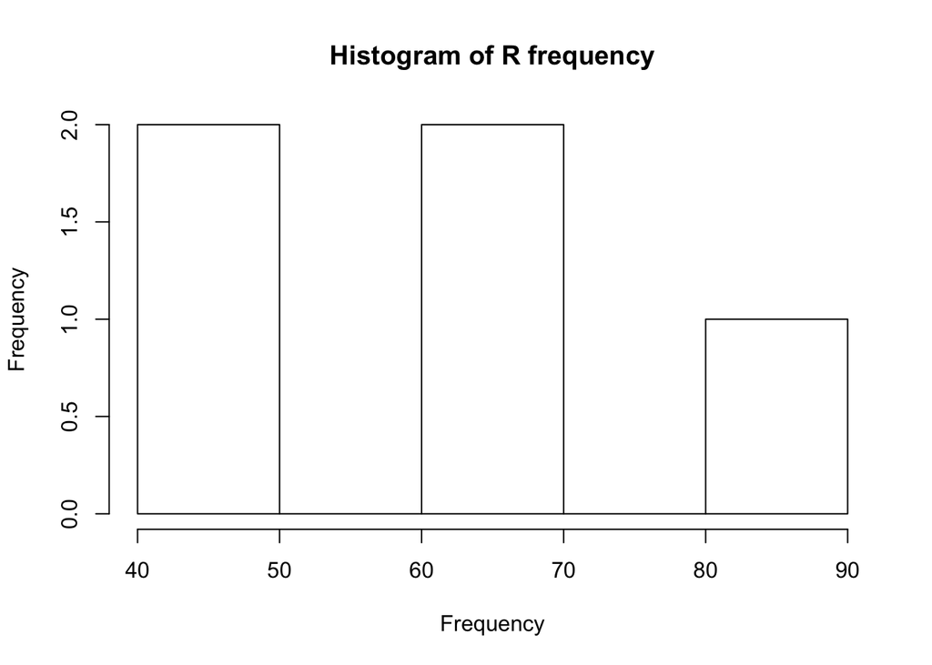

```r
hist(taula_freq2[2:6,1],
     main="Histogram of R frequency",
     xlab="Frequency")
```

```r
hist(taula_freq2[2:6,2],
     main="Histogram of Excel frequency",
     xlab="Frequency")
```

[output not shown]

```r
v3=rnorm(200, mean=10,sd=1)
taula_v3=data.frame(x3=v3)
#Definition of the intervals, categories to be used.
taula_v3_cat=transform(taula_v3, cat =
                         ifelse(x3 < -1,"-1",
                                ifelse(x3 < -0.5,"-0.5",
                                       ifelse(x3 < 0,"0",
                                              ifelse(x3 < 0.5,"0.5",
                                                     ifelse(x3 <1,"1","Inf"))))))
ExcelPract1Estadistica=transform(ExcelPract1Estadistica, Categoria =
                                   ifelse(SPECIAL < -1,"-1",
                                          ifelse(SPECIAL < -0.5,"-0.5",
                                                 ifelse(SPECIAL < 0,"0",
                                                        ifelse(SPECIAL < 0.5,"0.5",
                                                               ifelse(SPECIAL <1,"1","Inf"))))))
#Counting the amount of elements in each category “table” function.
taula_freq_v3=as.data.frame(with(taula_v3_cat, table(cat)))
taula_freq_excel3=as.data.frame(with(ExcelPract1Estadistica, table(Categoria)))

#Creation of the table containing the frequencies of both ditributions
taula_freq3=data.frame(x1=taula_freq_v3[2],x2=taula_freq_excel3[2])

#Chisquare test
Test=chisq.test(taula_freq3, correct=FALSE)
Test
```

```
##
##  Pearson's Chi-squared test
##
## data:  taula_freq3
## X-squared = 4.2067, df = 5, p-value = 0.52
```

As we can see below, the data from the excel is the same or very similiar due randomness, but the data from the new random distribution, as his mean is 10, the histogram is not correct. To correct that, we had too change the table in the variable “taula_v3_cat”.

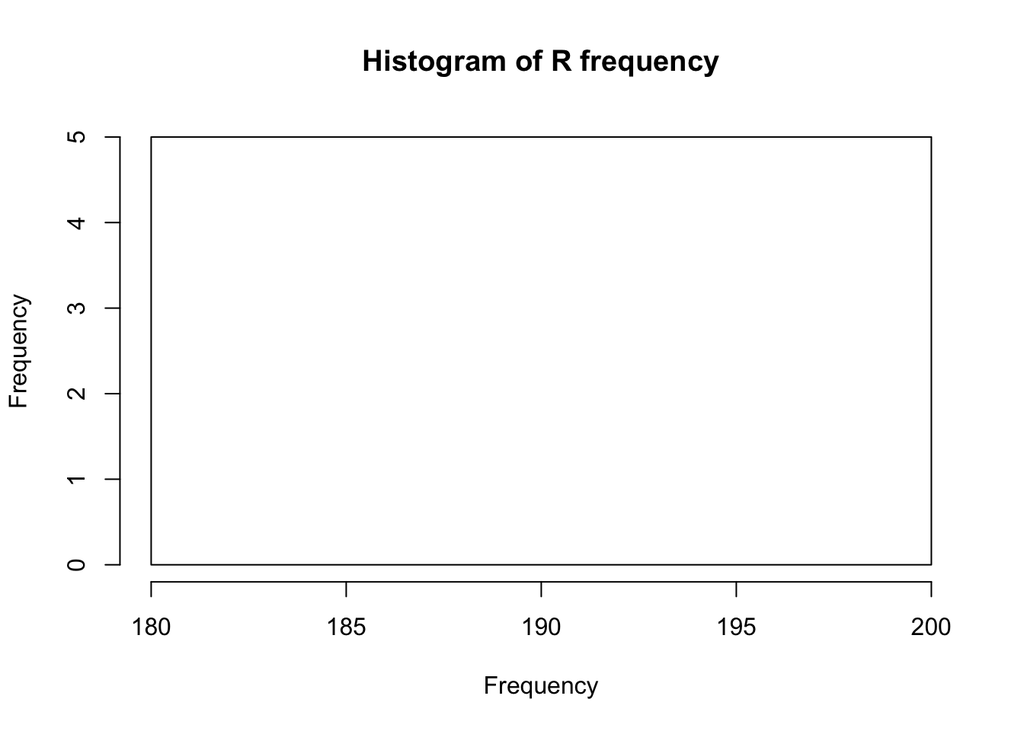

```r
hist(taula_freq3[2:6,1],
     main="Histogram of R frequency",
     xlab="Frequency")
```

```r
hist(taula_freq3[2:6,2],
     main="Histogram of Excel frequency",
     xlab="Frequency")
```

[output not shown]

#### Conclusions

As we can see in the histograms, the results of the R and Excel distributions are different but also are really similar. But, if we change the distributions, we can get very different results. It is important to use the same distribution either excel and R and also similar means.

## SECOND QUESTION: ANOVA.

Here, three random normal distributions are generated, one with a mean of 10 and the other ones with a mean of 0.

Then, the datais merged and a boxplot is applied.

Also, we will be testing if the populations from the rnorm are really normal. To see the diference, I’ve created and exponential population. The p-value of the exponential population is 0.

```r
#Provided code
library(RcmdrMisc)
Norm_v1=rnorm(200, mean=0, sd=1)
Norm_v2=rnorm(200, mean=10, sd=1)
Norm_v3=rnorm(200, mean=0, sd=1)
exp = rexp(200, rate=1)

shapiro.test(Norm_v1)
```

```
##
##  Shapiro-Wilk normality test
##
## data:  Norm_v1
## W = 0.99518, p-value = 0.776
```

```r
shapiro.test(Norm_v2)
```

```
##
##  Shapiro-Wilk normality test
##
## data:  Norm_v2
## W = 0.99554, p-value = 0.8263
```

```r
shapiro.test(Norm_v3)
```

```
##
##  Shapiro-Wilk normality test
##
## data:  Norm_v3
## W = 0.99216, p-value = 0.3592
```

```r
shapiro.test(exp)
```

```
##
##  Shapiro-Wilk normality test
##
## data:  exp
## W = 0.85215, p-value = 5.474e-13
```

```r
Norm_v1n=data.frame(x1=Norm_v1, x2="v1")
Norm_v2n=data.frame(x1=Norm_v2, x2="v2")
Norm_v3n=data.frame(x1=Norm_v3, x2="v3")
data=mergeRows(Norm_v1n, Norm_v2n, common.only=FALSE)
data=mergeRows(as.data.frame(data), Norm_v3n, common.only=FALSE)

AnovaModel1 <- aov(x1 ~ x2, data=data)
summary(AnovaModel1)
```

```
##              Df Sum Sq Mean Sq F value Pr(>F)
## x2            2  13122    6561    6297 <2e-16 ***
## Residuals   597    622       1
## ---
## Signif. codes:  0 '***' 0.001 '**' 0.01 '*' 0.05 '.' 0.1 ' ' 1
```

What is seen in this boxplot is the representation of the three random normal distributions that we created on the first part of the exercice.

It is clear that the distribution with mean 10 stays, of course, on the value 10 and the other two stay on the 0, because their mean is 0.

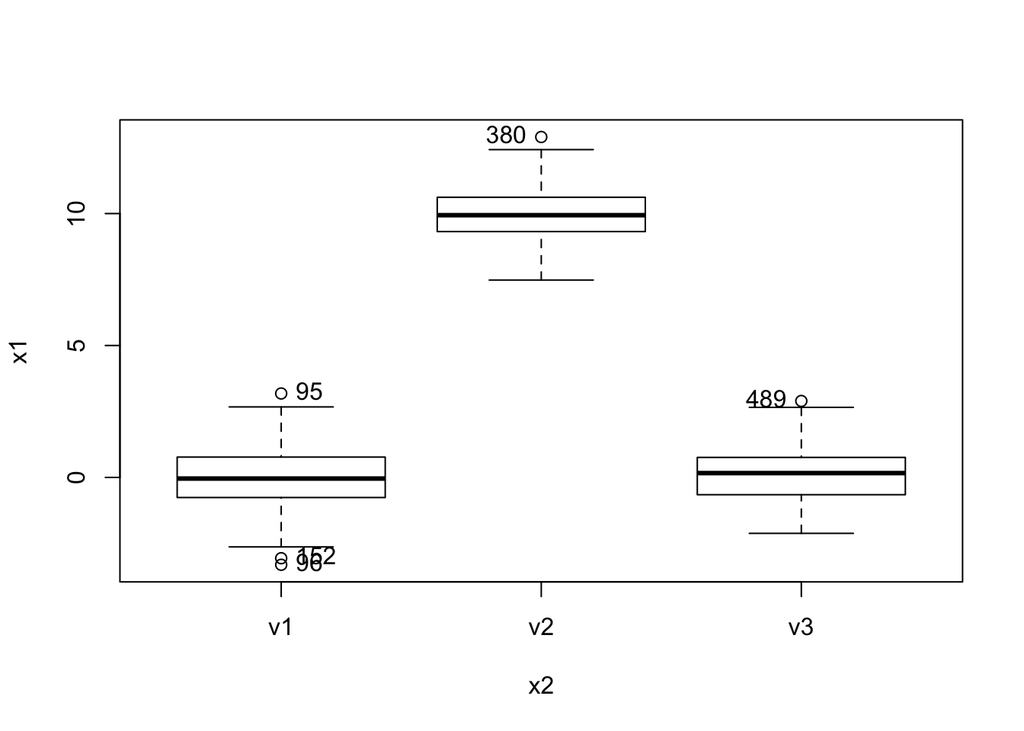

```
## [1] "96"  "152" "95"  "380" "489"
```

```r
Boxplot(x1~x2, data=data, id.method="y")
```

This test tests the indepency of the variables in the data set.

```r
lmtest::dwtest(AnovaModel1, alternative = "two.sided")
```

```
##
##  Durbin-Watson test
##
## data:  AnovaModel1
## DW = 1.926, p-value = 0.3221
## alternative hypothesis: true autocorrelation is not 0
```

This test, tests the homogenity of the model.

```r
lmtest::bptest(AnovaModel1)
```

```
##
##  studentized Breusch-Pagan test
##
## data:  AnovaModel1
## BP = 3.5871, df = 2, p-value = 0.1664
```

```r
library("lmtest", lib.loc="~/Library/R/3.3/library")
#Now we'll implement the tests using the library lmtest in order eto test the ANOVA
```

First of all, we will test the normality of the populations of the drift realted to block.size.medium. In order to do that, we extract the unique values from geomorphology$drift, and then, subset the data from geomorphology, selecting the correct data realted to the correspondent Drift and performing the test.

Organic soil have less than 3 variables, so, the test cant be performed on that population. That’s very important when performing shapiro tests, because, that’s another cause for what this Anova model can’t be trusted.

```r
data(geomorphology, package="FactoMineR")
uniqueNames = data.frame(unique(geomorphology$Drift))
#Test for each drift population
for(i in 1:nrow(uniqueNames)){
  shapiroData <- subset(geomorphology, Drift==as.character(uniqueNames$unique.geomorphology.Drift.[i]),select = Block.size.median)
  print("Shapiro test on: ")
  print(as.character(uniqueNames$unique.geomorphology.Drift.[i]))
  if(nrow(shapiroData)>3) {
    print(shapiro.test(shapiroData$Block.size.median))
    }
  else{print("Must have 3 or more rows in order to perform the shapiro test.")}
  }
```

```
## [1] "Shapiro test on: "
## [1] "Diamict"
##
##  Shapiro-Wilk normality test
##
## data:  shapiroData$Block.size.median
## W = 0.63431, p-value = 1.412e-09
##
## [1] "Shapiro test on: "
## [1] "Beach"
##
##  Shapiro-Wilk normality test
##
## data:  shapiroData$Block.size.median
## W = 0.70086, p-value = 0.0004798
##
## [1] "Shapiro test on: "
## [1] "Landslide"
##
##  Shapiro-Wilk normality test
##
## data:  shapiroData$Block.size.median
## W = 0.90435, p-value = 0.4344
##
## [1] "Shapiro test on: "
## [1] "Terraces"
##
##  Shapiro-Wilk normality test
##
## data:  shapiroData$Block.size.median
## W = 0.8471, p-value = 0.1491
##
## [1] "Shapiro test on: "
## [1] "Kame"
##
##  Shapiro-Wilk normality test
##
## data:  shapiroData$Block.size.median
## W = 0.92619, p-value = 0.5706
##
## [1] "Shapiro test on: "
## [1] "Organic soil"
## [1] "Must have 3 or more rows in order to perform the shapiro test."
```

Now, the anova model will be created and tested for 2 more assumptions, independency and homogeniety.

```r
Anova2 <- aov(Block.size.median ~ Drift ,data= geomorphology)
#Independent test
lmtest::dwtest(formula = Anova2,alternative = "two.sided")
```

```
##
##  Durbin-Watson test
##
## data:  Anova2
## DW = 2.1729, p-value = 0.6481
## alternative hypothesis: true autocorrelation is not 0
```

```r
#Homogenety tests
lmtest::bptest(Anova2)
```

```
##
##  studentized Breusch-Pagan test
##
## data:  Anova2
## BP = 3.336, df = 5, p-value = 0.6483
```

After that, we can create a boxplot in order to see the data in a more visual way.

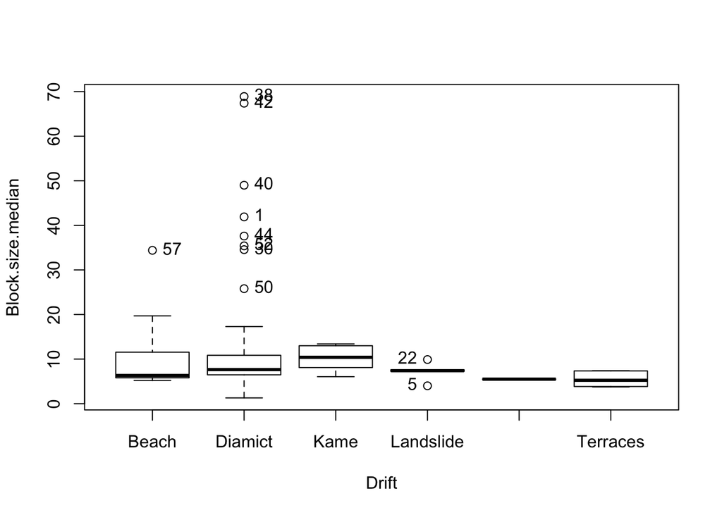

```
##  [1] "57" "1"  "30" "38" "40" "42" "44" "50" "52" "5"  "22"
```

```r
Boxplot(Block.size.median ~ Drift, data=geomorphology, id.method="y")
```

Now, we will do the same than before, but, for the population of Drift and Wind.

```r
for(i in 1:nrow(uniqueNames)){
  shapiroData <- subset(geomorphology, Drift==as.character(uniqueNames$unique.geomorphology.Drift.[i]),select = Wind.effect)
  print("Shapiro test on: ")
  print(as.character(uniqueNames$unique.geomorphology.Drift.[i]))
  if(nrow(shapiroData)>3) {
    print(shapiro.test(shapiroData$Wind.effect))
  }
  else{print("Must have 3 or more rows in order to perform the shapiro test.")}
}
```

```
## [1] "Shapiro test on: "
## [1] "Diamict"
##
##  Shapiro-Wilk normality test
##
## data:  shapiroData$Wind.effect
## W = 0.92158, p-value = 0.003793
##
## [1] "Shapiro test on: "
## [1] "Beach"
##
##  Shapiro-Wilk normality test
##
## data:  shapiroData$Wind.effect
## W = 0.93861, p-value = 0.5043
##
## [1] "Shapiro test on: "
## [1] "Landslide"
##
##  Shapiro-Wilk normality test
##
## data:  shapiroData$Wind.effect
## W = 0.84514, p-value = 0.1796
##
## [1] "Shapiro test on: "
## [1] "Terraces"
##
##  Shapiro-Wilk normality test
##
## data:  shapiroData$Wind.effect
## W = 0.79755, p-value = 0.05586
##
## [1] "Shapiro test on: "
## [1] "Kame"
##
##  Shapiro-Wilk normality test
##
## data:  shapiroData$Wind.effect
## W = 0.82027, p-value = 0.1173
##
## [1] "Shapiro test on: "
## [1] "Organic soil"
## [1] "Must have 3 or more rows in order to perform the shapiro test."
```

Now, like before, we create the anova and do the other two asumptions, as we can see, the Durbin-Watson test give un a p-value of 0.002, lower than 0.05, so, we can’t aprobe this assumption, so, the model can’t be trusted.

```r
Anova3 <- aov(Wind.effect ~ Drift ,data= geomorphology)
#Independent test
lmtest::dwtest(formula = Anova3,alternative = "two.sided")
```

```
##
##  Durbin-Watson test
##
## data:  Anova3
## DW = 1.3944, p-value = 0.002758
## alternative hypothesis: true autocorrelation is not 0
```

```r
#Homogenety tests
lmtest::bptest(Anova3)
```

```
##
##  studentized Breusch-Pagan test
##
## data:  Anova3
## BP = 5.0113, df = 5, p-value = 0.4145
```

The boxplot shows the population of Drift and Windeffect. As before, a value is missing, thats why, like before, the Drift value “organic soil” only have 1 value, so can not be computed.

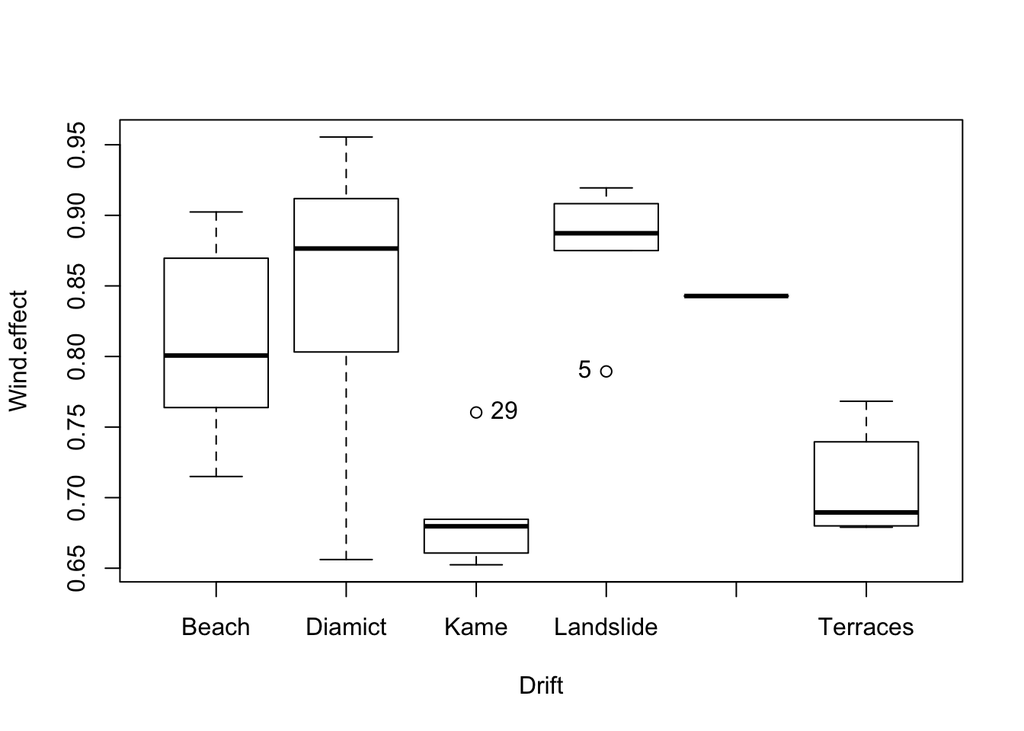

```
## [1] "29" "5"
```

```r
Boxplot(Wind.effect ~ Drift, data=geomorphology, id.method="y")
```

## THIRD QUESTION: DEFINE A LINEAR MODEL FOR AN ATHLETE IN THE 1500 M.

For this part of the exericice, a new data frame will be used. In this case, the data frame “Decathlon” will be used.

```r
data(decathlon, package="FactoMineR")
```

First of all, we need to change some names of the variables, because, if not, we could not acces these variables correctly.

```r
colnames(decathlon)[10] <- "D1500M"
colnames(decathlon)[5] <- "D400M"
colnames(decathlon)[1] <- "D100M"
```

Here we create the liniar model, looking for the regresion between D1500M and all the other variables.

```r
RegModel1 <- lm(D1500M~., data=decathlon)
RegModel1
```

```
##
## Call:
## lm(formula = D1500M ~ ., data = decathlon)
##
## Coefficients:
##         (Intercept)                D100M            Long.jump
##           1.411e+03           -3.711e+01            3.947e+01
##            Shot.put            High.jump                D400M
##           9.984e+00            1.470e+02           -7.680e+00
##       `110m.hurdle`               Discus           Pole.vault
##          -1.951e+01            3.461e+00            4.855e+01
##            Javeline                 Rank               Points
##           2.442e+00            3.099e-04           -1.632e-01
## CompetitionOlympicG
##           1.387e-01
```

Here is the summary of the liniar model we just created, as we can see, the model have and R-squared of 0.9975, we will try to improbe this value.

```r
summary(RegModel1)
```

```
##
## Call:
## lm(formula = D1500M ~ ., data = decathlon)
##
## Residuals:
##      Min       1Q   Median       3Q      Max
## -1.11082 -0.40320 -0.02978  0.37054  0.99005
##
## Coefficients:
##                       Estimate Std. Error t value Pr(>|t|)
## (Intercept)          1.411e+03  2.281e+01  61.851   <2e-16 ***
## D100M               -3.711e+01  6.090e-01 -60.937   <2e-16 ***
## Long.jump            3.947e+01  6.635e-01  59.489   <2e-16 ***
## Shot.put             9.984e+00  2.172e-01  45.972   <2e-16 ***
## High.jump            1.470e+02  2.538e+00  57.931   <2e-16 ***
## D400M               -7.680e+00  2.351e-01 -32.670   <2e-16 ***
## `110m.hurdle`       -1.951e+01  3.730e-01 -52.320   <2e-16 ***
## Discus               3.461e+00  5.077e-02  68.184   <2e-16 ***
## Pole.vault           4.855e+01  6.462e-01  75.127   <2e-16 ***
## Javeline             2.442e+00  4.648e-02  52.533   <2e-16 ***
## Rank                 3.099e-04  4.278e-02   0.007    0.994
## Points              -1.632e-01  2.566e-03 -63.589   <2e-16 ***
## CompetitionOlympicG  1.387e-01  5.532e-01   0.251    0.804
## ---
## Signif. codes:  0 '***' 0.001 '**' 0.01 '*' 0.05 '.' 0.1 ' ' 1
##
## Residual standard error: 0.5796 on 28 degrees of freedom
## Multiple R-squared:  0.9983, Adjusted R-squared:  0.9975
## F-statistic:  1350 on 12 and 28 DF,  p-value: < 2.2e-16
```

Now we do the testing for the regmodel 1. As we can see, the tests are correct, the p-value is higher than 0.05 and the other values make sense.

```r
#Independicy test
lmtest::dwtest(RegModel1, alternative = "two.sided")
```

```
##
##  Durbin-Watson test
##
## data:  RegModel1
## DW = 1.7501, p-value = 0.1774
## alternative hypothesis: true autocorrelation is not 0
```

```r
#homogenity test
lmtest::bptest(RegModel1)
```

```
##
##  studentized Breusch-Pagan test
##
## data:  RegModel1
## BP = 18.152, df = 12, p-value = 0.1111
```

```r
#Normality test
shapiro.test(residuals(RegModel1))
```

```
##
##  Shapiro-Wilk normality test
##
## data:  residuals(RegModel1)
## W = 0.98298, p-value = 0.7869
```

In order to improbe the r-squared, we will remove some variables that are non quantitative, for example, first, we will remove the rank. As we can see, the value now is 0.9976, it has improbed. We can also see that the asumptions are correct and we can trust the model.

```r
RegModel2 <- lm(D1500M~. -Rank, data=decathlon)
RegModel2
```

```
##
## Call:
## lm(formula = D1500M ~ . - Rank, data = decathlon)
##
## Coefficients:
##         (Intercept)                D100M            Long.jump
##           1410.6405             -37.1095              39.4715
##            Shot.put            High.jump                D400M
##              9.9841             147.0274              -7.6801
##       `110m.hurdle`               Discus           Pole.vault
##            -19.5146               3.4615              48.5491
##            Javeline               Points  CompetitionOlympicG
##              2.4421              -0.1632               0.1421
```

```r
summary(RegModel2)
```

```
##
## Call:
## lm(formula = D1500M ~ . - Rank, data = decathlon)
##
## Residuals:
##      Min       1Q   Median       3Q      Max
## -1.11067 -0.40263 -0.03038  0.37118  0.98839
##
## Coefficients:
##                       Estimate Std. Error t value Pr(>|t|)
## (Intercept)          1.411e+03  1.848e+01  76.327   <2e-16 ***
## D100M               -3.711e+01  5.961e-01 -62.259   <2e-16 ***
## Long.jump            3.947e+01  6.323e-01  62.424   <2e-16 ***
## Shot.put             9.984e+00  2.101e-01  47.525   <2e-16 ***
## High.jump            1.470e+02  2.415e+00  60.882   <2e-16 ***
## D400M               -7.680e+00  2.218e-01 -34.623   <2e-16 ***
## `110m.hurdle`       -1.951e+01  3.549e-01 -54.990   <2e-16 ***
## Discus               3.462e+00  4.890e-02  70.787   <2e-16 ***
## Pole.vault           4.855e+01  6.274e-01  77.387   <2e-16 ***
## Javeline             2.442e+00  4.306e-02  56.716   <2e-16 ***
## Points              -1.632e-01  2.019e-03 -80.805   <2e-16 ***
## CompetitionOlympicG  1.421e-01  2.850e-01   0.499    0.622
## ---
## Signif. codes:  0 '***' 0.001 '**' 0.01 '*' 0.05 '.' 0.1 ' ' 1
##
## Residual standard error: 0.5695 on 29 degrees of freedom
## Multiple R-squared:  0.9983, Adjusted R-squared:  0.9976
## F-statistic:  1525 on 11 and 29 DF,  p-value: < 2.2e-16
```

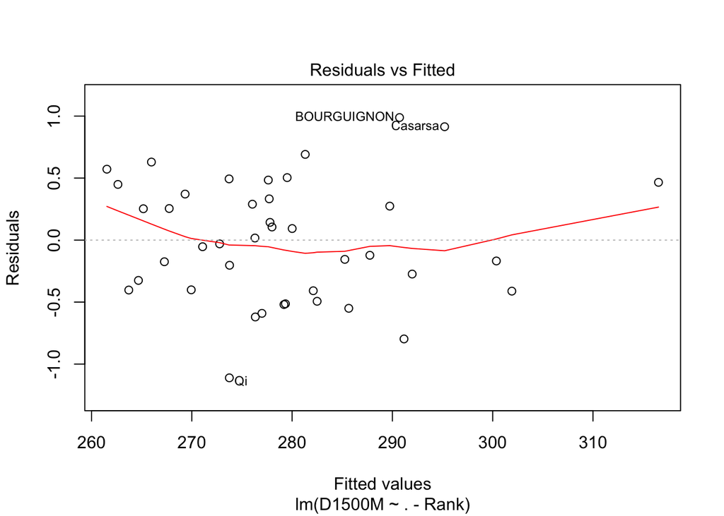

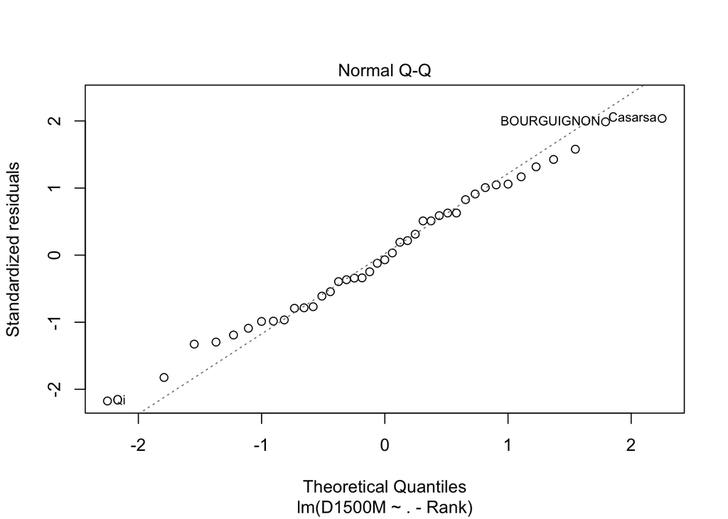

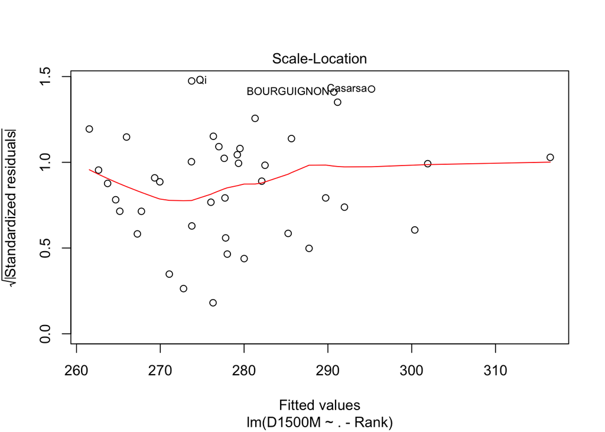

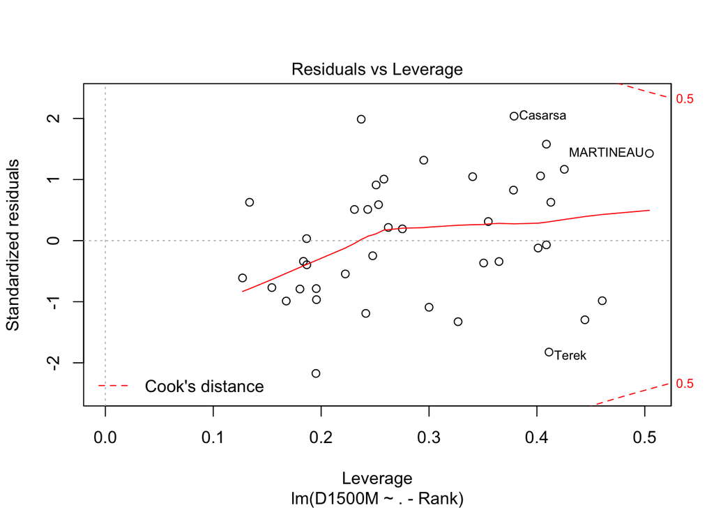

```r
plot(RegModel2)
```

```r
#Independicy test
lmtest::dwtest(RegModel2, alternative = "two.sided")
```

```
##
##  Durbin-Watson test
##
## data:  RegModel2
## DW = 1.7501, p-value = 0.2376
## alternative hypothesis: true autocorrelation is not 0
```

```r
#homogenity test
lmtest::bptest(RegModel2)
```

```
##
##  studentized Breusch-Pagan test
##
## data:  RegModel2
## BP = 18.004, df = 11, p-value = 0.08148
```

```r
#Normality test
shapiro.test(residuals(RegModel2))
```

```
##
##  Shapiro-Wilk normality test
##
## data:  residuals(RegModel2)
## W = 0.98286, p-value = 0.7823
```

Finally, we will do the same but removing also the variable competition for the exact same reason. The R-squared value has been improbed to 0.9977. We can see also that the asumptions are correct, so, we can trust the model

```r
RegModel3 <- lm(D1500M~. -Rank -Competition, data=decathlon)
RegModel3
```

```
##
## Call:
## lm(formula = D1500M ~ . - Rank - Competition, data = decathlon)
##
## Coefficients:
##   (Intercept)          D100M      Long.jump       Shot.put      High.jump
##     1408.7875       -37.2096        39.3428         9.9829       146.4474
##         D400M  `110m.hurdle`         Discus     Pole.vault       Javeline
##       -7.6274       -19.4683         3.4506        48.3886         2.4344
##        Points
##       -0.1627
```

```r
summary(RegModel3)
```

```
##
## Call:
## lm(formula = D1500M ~ . - Rank - Competition, data = decathlon)
##
## Residuals:
##      Min       1Q   Median       3Q      Max
## -1.04641 -0.38236 -0.07186  0.39878  0.94814
##
## Coefficients:
##                 Estimate Std. Error t value Pr(>|t|)
## (Intercept)    1.409e+03  1.788e+01   78.81   <2e-16 ***
## D100M         -3.721e+01  5.541e-01  -67.15   <2e-16 ***
## Long.jump      3.934e+01  5.699e-01   69.03   <2e-16 ***
## Shot.put       9.983e+00  2.074e-01   48.13   <2e-16 ***
## High.jump      1.464e+02  2.090e+00   70.08   <2e-16 ***
## D400M         -7.627e+00  1.926e-01  -39.60   <2e-16 ***
## `110m.hurdle` -1.947e+01  3.382e-01  -57.57   <2e-16 ***
## Discus         3.451e+00  4.311e-02   80.05   <2e-16 ***
## Pole.vault     4.839e+01  5.317e-01   91.00   <2e-16 ***
## Javeline       2.434e+00  3.966e-02   61.38   <2e-16 ***
## Points        -1.627e-01  1.789e-03  -90.99   <2e-16 ***
## ---
## Signif. codes:  0 '***' 0.001 '**' 0.01 '*' 0.05 '.' 0.1 ' ' 1
##
## Residual standard error: 0.5623 on 30 degrees of freedom
## Multiple R-squared:  0.9983, Adjusted R-squared:  0.9977
## F-statistic:  1721 on 10 and 30 DF,  p-value: < 2.2e-16
```

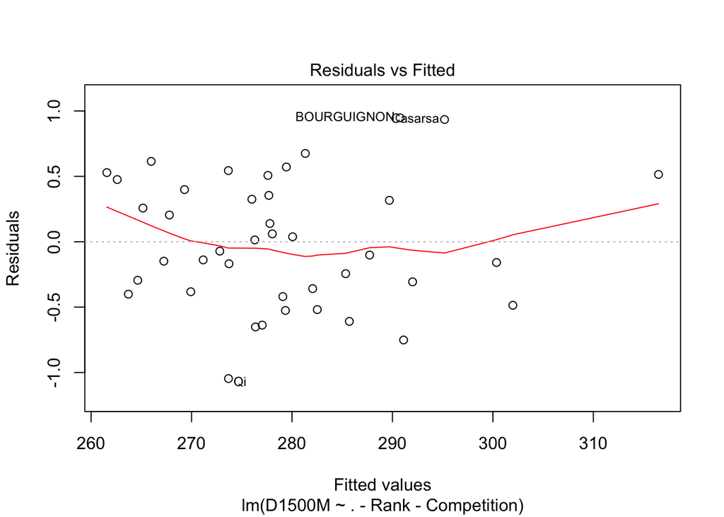

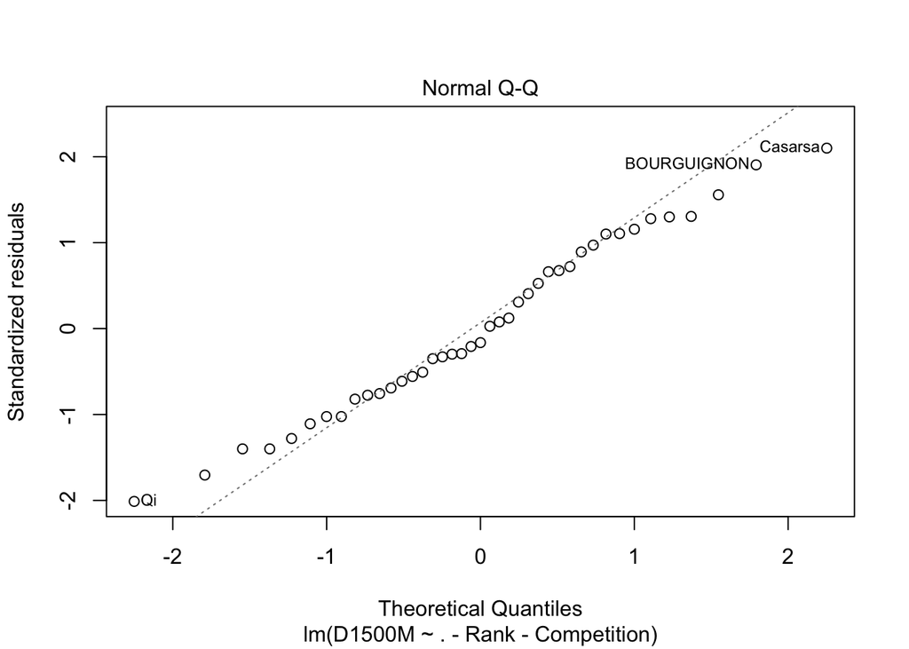

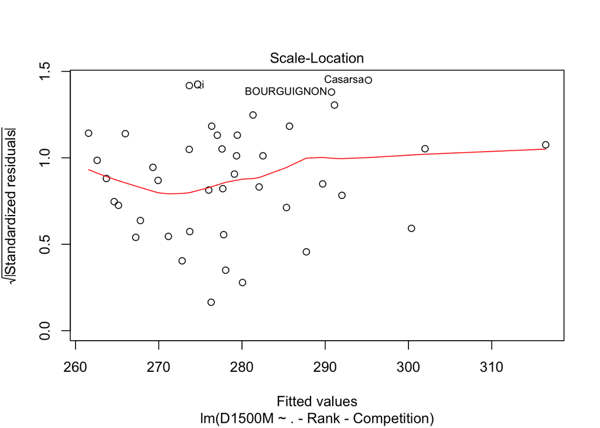

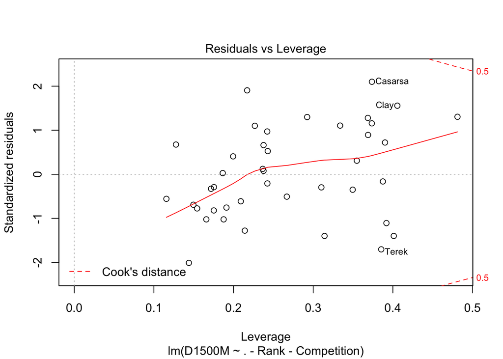

```r
plot(RegModel3)
```

```r
#Independicy test
lmtest::dwtest(RegModel3, alternative = "two.sided")
```

```
##
##  Durbin-Watson test
##
## data:  RegModel3
## DW = 1.6852, p-value = 0.2082
## alternative hypothesis: true autocorrelation is not 0
```

```r
#homogenity test
lmtest::bptest(RegModel3)
```

```
##
##  studentized Breusch-Pagan test
##
## data:  RegModel3
## BP = 16.954, df = 10, p-value = 0.07539
```

```r
#Normality test
shapiro.test(residuals(RegModel3))
```

```
##
##  Shapiro-Wilk normality test
##
## data:  residuals(RegModel3)
## W = 0.9769, p-value = 0.5604
```

## FOURTH QUESTION: USE THE MODEL TO PREDICT THE BEHAVIOR OF AN ATHLETE.

Now, we want to predict the behaviour of an athelte, in order to do that, we will use the function predict. Those models will predict the behaviour of an athlete, running 1500M, in prediction interval the first one and confidence the second one.

Here, we see predicitons for the model 3, so, it’s the prediction of athletes running the 1500M but without the variables rank and competition.

```r
predict(RegModel3, newdata=decathlon, interval="prediction")
```

```
##                  fit      lwr      upr
## SEBRLE      292.0066 290.7438 293.2693
## CLAY        301.9859 300.6310 303.3408
## KARPOV      300.3589 299.0248 301.6930
## BERNARD     280.0619 278.7843 281.3395
## YURKOV      277.0376 275.7722 278.3030
## WARNERS     278.0398 276.7627 279.3169
## ZSIVOCZKY   267.7956 266.5379 269.0534
## McMULLEN    285.3444 284.0518 286.6370
## MARTINEAU   261.5713 260.1737 262.9690
## HERNU       285.7091 284.3498 287.0685
## BARRAS      282.5189 281.2675 283.7704
## NOOL        265.9854 264.6799 267.2910
## BOURGUIGNON 290.7519 289.4849 292.0188
## Sebrle      279.4385 278.0950 280.7820
## Clay        281.3249 279.9634 282.6865
## Karpov      277.6027 276.2764 278.9290
## Macey       265.1626 263.8823 266.4429
## Warners     277.6955 276.4760 278.9150
## Zsivoczky   269.9224 268.6690 271.1757
## Hernu       264.6447 263.4317 265.8577
## Nool        276.0050 274.7274 277.2826
## Bernard     276.2963 275.0454 277.5472
## Schwarzl    273.7283 272.4852 274.9714
## Pogorelov   287.7318 286.4517 289.0119
## Schoenbeck  279.3457 278.1058 280.5857
## Barras      267.2389 265.9938 268.4839
## Smith       272.8119 271.4591 274.1646
## Averyanov   271.1589 269.8444 272.4735
## Ojaniemi    276.3619 275.0453 277.6784
## Smirnov     263.7110 262.4771 264.9448
## Qi          273.6764 272.4481 274.9047
## Drews       273.6660 272.3940 274.9379
## Parkhomenko 277.8006 276.4639 279.1373
## Terek       291.1114 289.7597 292.4631
## Gomez       269.3012 267.9576 270.6448
## Turi        289.6932 288.3392 291.0473
## Lorenzo     262.6045 261.3245 263.8845
## Karlivans   279.0893 277.8443 280.3342
## Korkizoglou 316.4853 315.1394 317.8313
## Uldal       282.0585 280.8272 283.2898
## Casarsa     295.1854 293.8394 296.5314
```

```r
predict(RegModel3, newdata=decathlon, interval="confidence")
```

```
##                  fit      lwr      upr
## SEBRLE      292.0066 291.4815 292.5317
## CLAY        301.9859 301.2670 302.7049
## KARPOV      300.3589 299.6799 301.0379
## BERNARD     280.0619 279.5021 280.6217
## YURKOV      277.0376 276.5062 277.5690
## WARNERS     278.0398 277.4812 278.5985
## ZSIVOCZKY   267.7956 267.2827 268.3085
## McMULLEN    285.3444 284.7511 285.9376
## MARTINEAU   261.5713 260.7747 262.3679
## HERNU       285.7091 284.9818 286.4365
## BARRAS      282.5189 282.0216 283.0163
## NOOL        265.9854 265.3644 266.6064
## BOURGUIGNON 290.7519 290.2168 291.2869
## Sebrle      279.4385 278.7412 280.1357
## Clay        281.3249 280.5935 282.0563
## Karpov      277.6027 276.9392 278.2662
## Macey       265.1626 264.5966 265.7286
## Warners     277.6955 277.2851 278.1059
## Zsivoczky   269.9224 269.4204 270.4244
## Hernu       264.6447 264.2541 265.0353
## Nool        276.0050 275.4452 276.5649
## Bernard     276.2963 275.8005 276.7921
## Schwarzl    273.7283 273.2523 274.2042
## Pogorelov   287.7318 287.1663 288.2973
## Schoenbeck  279.3457 278.8781 279.8134
## Barras      267.2389 266.7579 267.7198
## Smith       272.8119 272.0970 273.5267
## Averyanov   271.1589 270.5193 271.7986
## Ojaniemi    276.3619 275.7181 277.0056
## Smirnov     263.7110 263.2599 264.1620
## Qi          273.6764 273.2407 274.1121
## Drews       273.6660 273.1192 274.2128
## Parkhomenko 277.8006 277.1165 278.4846
## Terek       291.1114 290.3984 291.8243
## Gomez       269.3012 268.6038 269.9987
## Turi        289.6932 288.9759 290.4106
## Lorenzo     262.6045 262.0392 263.1698
## Karlivans   279.0893 278.6086 279.5699
## Korkizoglou 316.4853 315.7834 317.1873
## Uldal       282.0585 281.6144 282.5026
## Casarsa     295.1854 294.4833 295.8874
```

Now, i will repeat the predictons, but changing the model, now, the linear regression is between 1500M and 400M. As we can see, we can’t trust the model because the normality test is not passed, because the result of that test is 0.01

```r
#Prediction for 400 and 1500M
RegModel4 <- lm(D1500M~D400M, data=decathlon)
#Independicy test
lmtest::dwtest(RegModel4, alternative = "two.sided")
```

```
##
##  Durbin-Watson test
##
## data:  RegModel4
## DW = 1.7274, p-value = 0.3458
## alternative hypothesis: true autocorrelation is not 0
```

```r
#homogenity test
lmtest::bptest(RegModel4)
```

```
##
##  studentized Breusch-Pagan test
##
## data:  RegModel4
## BP = 0.0010727, df = 1, p-value = 0.9739
```

```r
#Normality test
shapiro.test(residuals(RegModel4))
```

```
##
##  Shapiro-Wilk normality test
##
## data:  residuals(RegModel4)
## W = 0.93244, p-value = 0.01742
```

```r
new <- data.frame(decathlon$D400M)
colnames(new)[1] <- "D400M"
predict(RegModel4, newdata=new, interval="prediction")
```

```
##         fit      lwr      upr
## 1  279.8247 257.7223 301.9272
## 2  278.0075 255.9003 300.1146
## 3  273.8773 251.4699 296.2847
## 4  276.1902 254.0001 298.3803
## 5  282.3441 260.1188 304.5695
## 6  275.1576 252.8858 297.4295
## 7  274.9098 252.6147 297.2050
## 8  280.2377 258.1254 302.3501
## 9  281.1877 259.0373 303.3380
## 10 285.1526 262.6161 307.6891
## 11 278.4618 256.3631 300.5604
## 12 277.3053 255.1754 299.4353
## 13 285.4004 262.8279 307.9730
## 14 273.8360 251.4236 296.2484
```

[output cut: 27 more lines]

```r
predict(RegModel4, newdata=new, interval="confidence")
```

```
##         fit      lwr      upr
## 1  279.8247 276.3665 283.2829
## 2  278.0075 274.5194 281.4955
## 3  273.8773 268.8242 278.9304
## 4  276.1902 272.2100 280.1703
## 5  282.3441 278.1719 286.5163
## 6  275.1576 270.7447 279.5706
## 7  274.9098 270.3807 279.4389
## 8  280.2377 276.7170 283.7585
## 9  281.1877 277.4355 284.9399
## 10 285.1526 279.5548 290.7504
## 11 278.4618 275.0281 281.8954
## 12 277.3053 273.6755 280.9352
## 13 285.4004 279.6592 291.1417
## 14 273.8360 268.7608 278.9112
```

[output cut: 27 more lines]

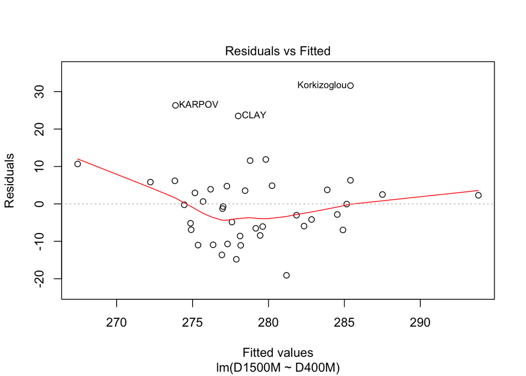

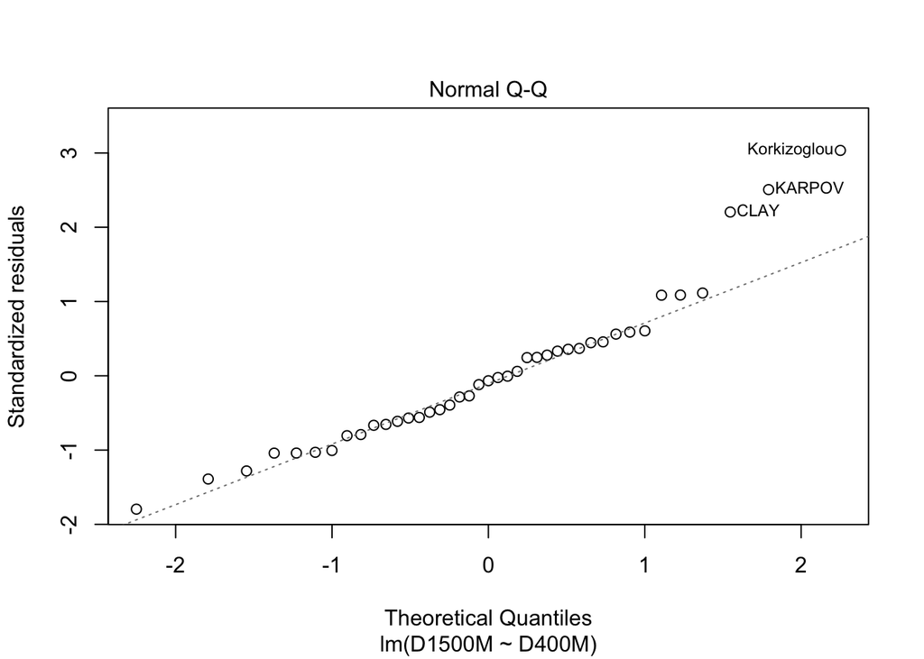

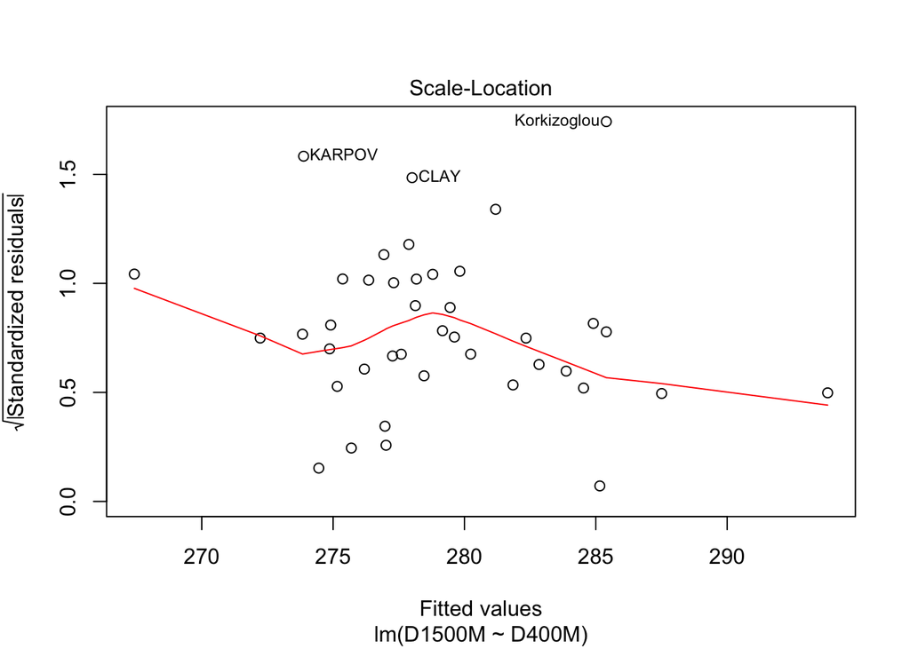

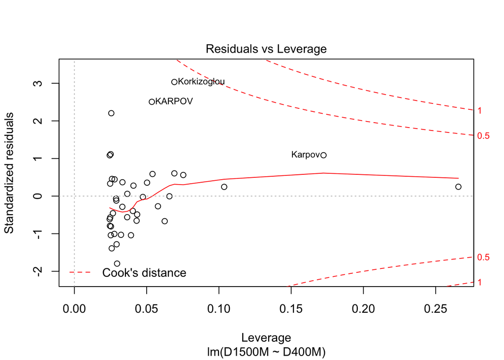

```r
plot(RegModel4)
```

As we can see in this case, we take the rank and we make a linear regresion with D100M, D400M, D1500M and points, the normality and homogenity test are correct, but the independency test is not correct, so, we can not trust this model.

```r
RegModel5 <- lm(Rank~ D100M + D400M + D1500M + Points, data=decathlon)
#Independicy test
lmtest::dwtest(RegModel5, alternative = "two.sided")
```

```
##
##  Durbin-Watson test
##
## data:  RegModel5
## DW = 1.0177, p-value = 0.000234
## alternative hypothesis: true autocorrelation is not 0
```

```r
#homogenity test
lmtest::bptest(RegModel5)
```

```
##
##  studentized Breusch-Pagan test
##
## data:  RegModel5
## BP = 5.336, df = 4, p-value = 0.2545
```

```r
#Normality test
shapiro.test(residuals(RegModel5))
```

```
##
##  Shapiro-Wilk normality test
##
## data:  residuals(RegModel5)
## W = 0.96839, p-value = 0.3052
```

```r
new <- data.frame(decathlon$D100M,decathlon$D400M,decathlon$D1500M,decathlon$Points)
colnames(new)[1] <- "D100M"
colnames(new)[2] <- "D400M"
colnames(new)[3] <- "D1500M"
colnames(new)[4] <- "Points"
predict(RegModel5, newdata=new, interval="prediction")
```

```
##          fit          lwr       upr
## 1   5.129548  -4.77801660 15.037113
## 2   8.985157  -1.10705576 19.077370
## 3   3.490774  -7.17014706 14.151695
## 4   8.795177  -0.84078200 18.431137
## 5   8.244398  -1.75898502 18.247782
## 6   7.991577  -1.78250454 17.765658
## 7   9.830749   0.05305836 19.608440
## 8  14.579245   4.92839094 24.230098
## 9  10.443006  -0.07702405 20.963036
## 10 14.315801   4.44214412 24.189458
## 11 12.562368   2.63105176 22.493684
## 12 15.820584   5.80943724 25.831732
## 13 22.589878  12.51808560 32.661670
## 14 -7.652281 -18.36016107  3.055599
```

[output cut: 27 more lines]

```r
predict(RegModel5, newdata=new, interval="confidence")
```

```
##          fit        lwr       upr
## 1   5.129548   2.058356  8.200741
## 2   8.985157   5.362293 12.608022
## 3   3.490774  -1.501983  8.483531
## 4   8.795177   6.764391 10.825964
## 5   8.244398   4.876898 11.611899
## 6   7.991577   5.382928 10.600226
## 7   9.830749   7.208609 12.452889
## 8  14.579245  12.478921 16.679568
## 9  10.443006   5.758627 15.127385
## 10 14.315801  11.355820 17.275782
## 11 12.562368   9.415398 15.709337
## 12 15.820584  12.430090 19.211078
## 13 22.589878  19.024295 26.155461
## 14 -7.652281 -12.744537 -2.560025
```

[output cut: 27 more lines]

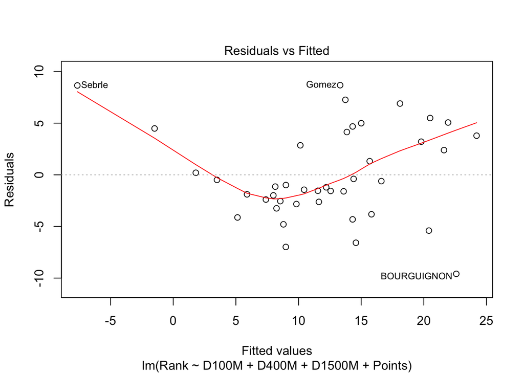

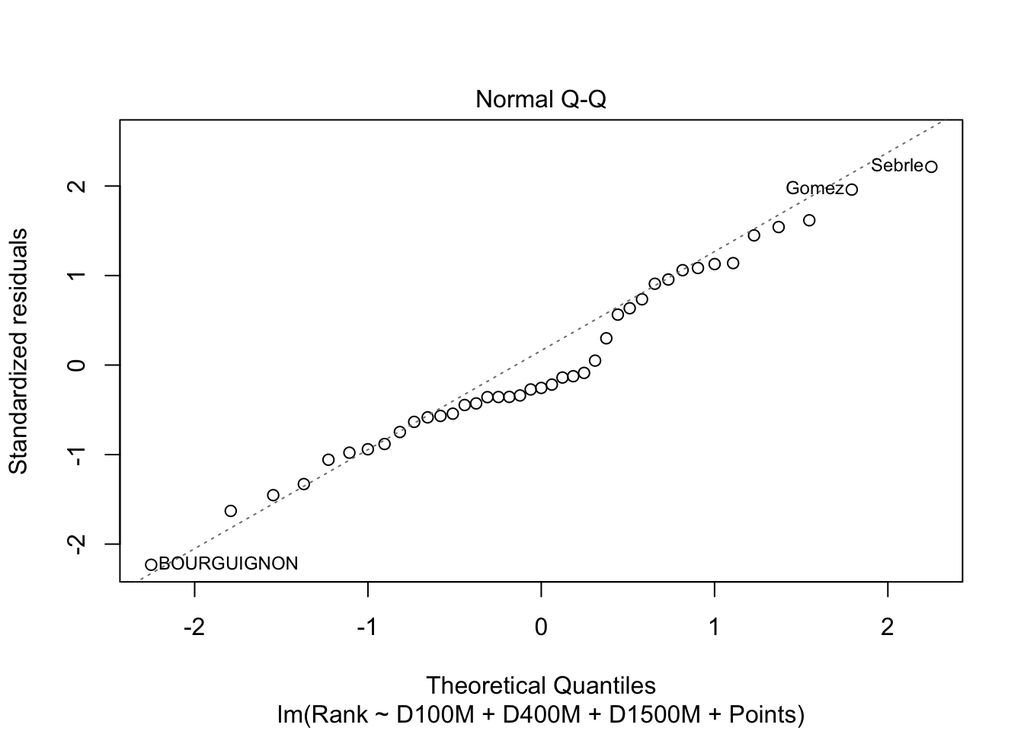

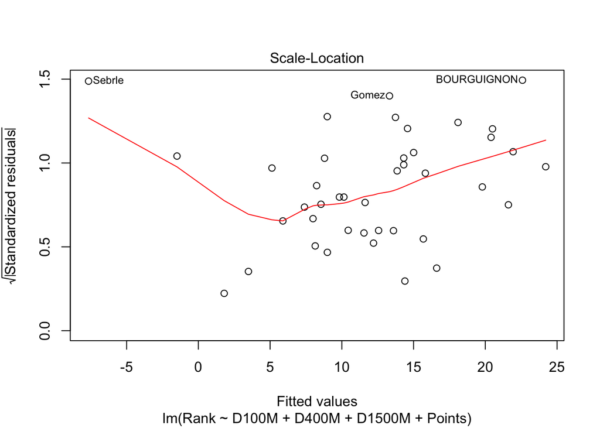

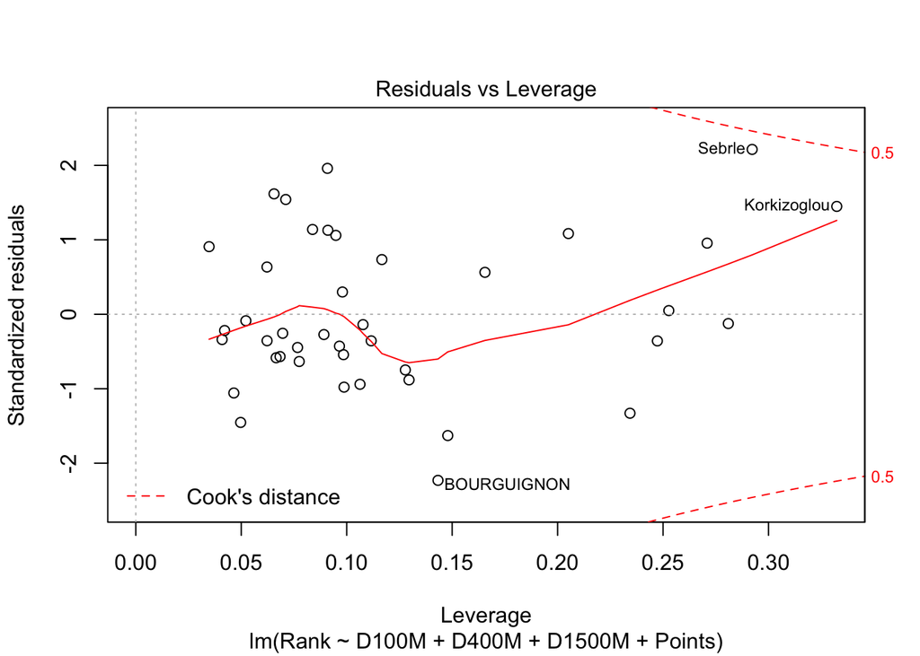

```r
plot (RegModel5)
```

## FIVE QUESTION: PCA

The final part is to create a PCA, in order to do that we will use the function PCA, but, we will delete the variables Rank and Competition for the same reason than before, for being qualitative data intead of quantitative. The library FactoMineR is mandatory in order to compute the PCA.

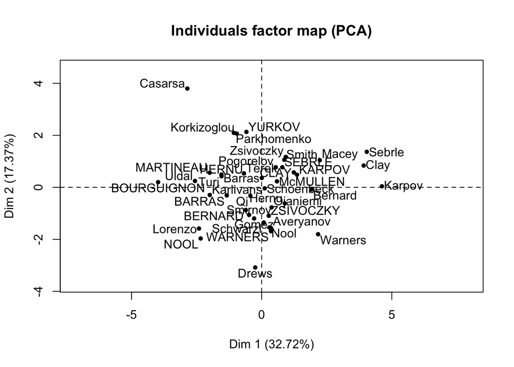

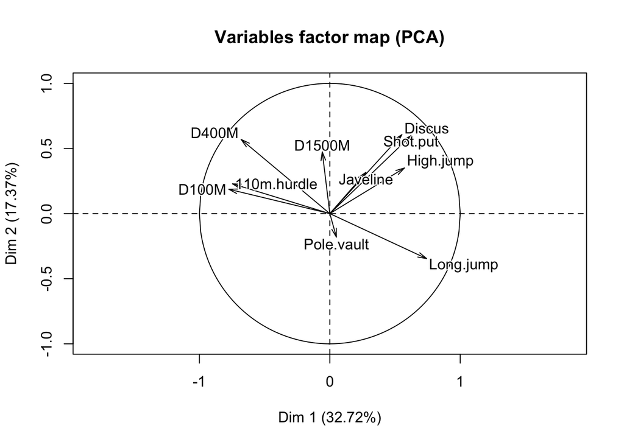

```
## **Results for the Principal Component Analysis (PCA)**
## The analysis was performed on 41 individuals, described by 10 variables
## *The results are available in the following objects:
##
##    name               description
## 1  "$eig"             "eigenvalues"
## 2  "$var"             "results for the variables"
## 3  "$var$coord"       "coord. for the variables"
## 4  "$var$cor"         "correlations variables - dimensions"
## 5  "$var$cos2"        "cos2 for the variables"
## 6  "$var$contrib"     "contributions of the variables"
## 7  "$ind"             "results for the individuals"
## 8  "$ind$coord"       "coord. for the individuals"
## 9  "$ind$cos2"        "cos2 for the individuals"
## 10 "$ind$contrib"     "contributions of the individuals"
## 11 "$call"            "summary statistics"
## 12 "$call$centre"     "mean of the variables"
## 13 "$call$ecart.type" "standard error of the variables"
## 14 "$call$row.w"      "weights for the individuals"
## 15 "$call$col.w"      "weights for the variables"
```

```r
library(FactoMineR)
pcaData <- subset( decathlon, select = -c(Competition,Rank,Points))
PCA(pcaData)
```

## CONCLUSIONS

In this asignment we have seen some diferent distributions and forms of expresing the data depending of what we are looking for.

One of the main points that have been covered is the mandatory and high importance of the assumptions on the models.

All the models have to be tested, because, without the tests, we can not know if that model can be trusted or not. It is true that most of the times, some tests are not done, for example, independency test is the one that we can be more flexible with, but, it is also important to have in mind that if a model do not pass the independency test, some problems can appear later on.

Also, the addition of excel in this asignment makes itself more interesting, also proves, that excel is a very usefull tool that a lot of companies use. Excel also is a very common way to provide us data to analyse, because a lot of companies use excels as a main data structure and analysis.